# Residualization by depth profiles

Michael Tassia

2026-10-04

## 0. Overview

This notebook serves to document the application of including additional technical covariates to regression designs following the strategies published originally in [Burren et al. 2024](https://www.nature.com/articles/s41588-024-01884-7) and subsequently applied in [Nakao et al. 2026](https://www.nature.com/articles/s41588-026-02567-1).

In brief, depth profiles per 1000-bp genomic bin were computed with [`mosdepth`](https://github.com/brentp/mosdepth), and PCA was performed on the whole pool of depth profiles using [`NGS-PCA`](https://github.com/PankratzLab/NGS-PCA). These PCs are then used to control for technical variation that arises during sequencing.

## 1. Data summary

### 1.1 Clone data

Below we summarize the clonal trait data by plotting [TelSeq](https://pmc.ncbi.nlm.nih.gov/articles/PMC4027178/) telomere length estimates against the adjusted clock-like mutation burden ($\frac{\textrm{clocklike burden}}{\textrm{sensitivity}}$), where *sensitivity* is the proportion of germline polymorphisms recovered per clone.

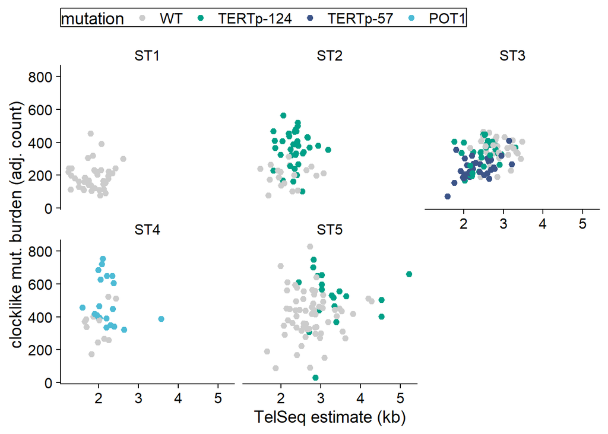

### 1.2 PCA data

As our data set is much smaller than the biobanks analyzed in [Burren et al. 2024](https://www.nature.com/articles/s41588-024-01884-7) and [Nakao et al. 2026](https://www.nature.com/articles/s41588-026-02567-1), we will use the elbow of this scree plot to select the top $k$ PCs to include as predictor variables. This avoids saturating the model and introducing instability in predictions as $N \approx P$.

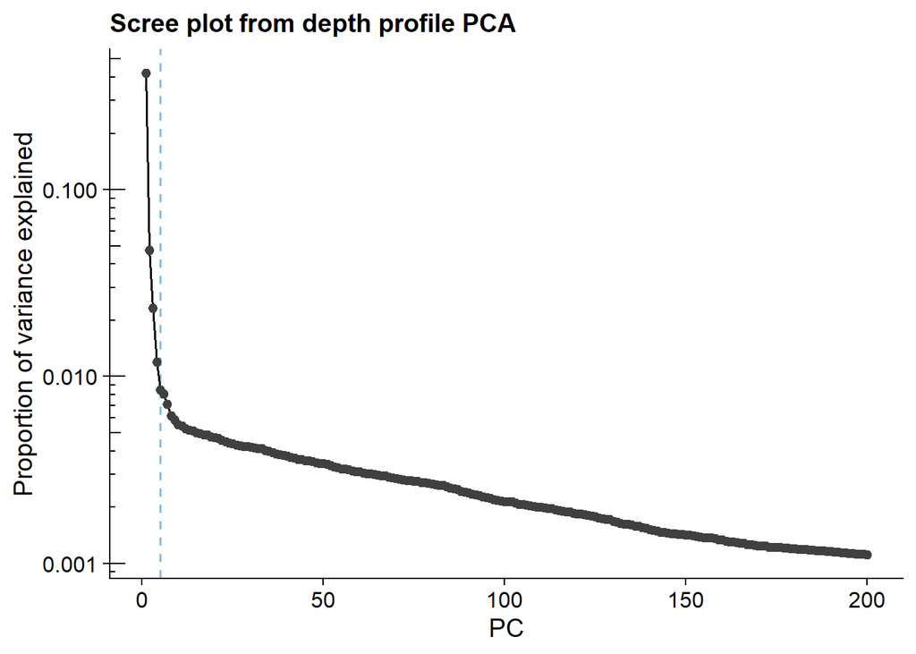

By projecting our samples onto the first two PCs, we see both *batch* and *individual* stratifying on PC1. Though not discussed in the manuscript, *batch* is nested within *individual*, causing *batch* to be fully aliased within the model.

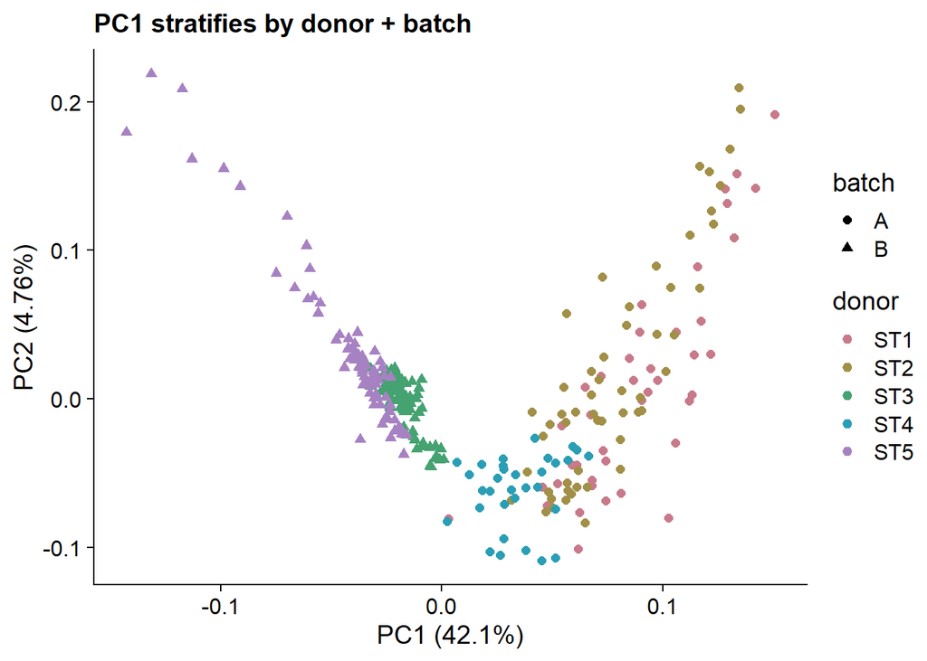

By regressing PC1 onto *individual*, we found that *individual* (and via aliasing, *batch*) explains 84.9 % of the variation captured by PC1.

## 2. TL regressions

Using the first $k =$ 5 PCs, we use linear mixed-effects models to estimate the effect of each mutation on telomere length.

To quantify the main effect of each mutation, we regress telomere length against *mutation*, *sensitivity* (defined above), and the principle components; *individual* is included as a random effect. This is critical for estimating main effects, as each level of the *mutation* term (i.e., *TERTp -124C>T, TERTp -57C>A,* and POT1 p.Y242C) is not balanced across each level of *individual*.

$$\textrm{telomere length} \sim
\textrm{mutation + sensitivity} + \sum_{i \in
1,...,k}^{k}\textrm{PC}_{i} + (1|\textrm{individual})
\tag{1}$$

To contrast the effect of each mutation within each individual, we adjust the model to include an interaction between *individual* and *mutant* as a main effect. This quantity is then used to perform contrasts within each individual using [estimated marginal means](https://rvlenth.github.io/emmeans/).

$$\textrm{telomere length} \sim
\textrm{mutation} \times \textrm{individual + sensitivity} + \sum_{i \in
1,...,k}^{k}\textrm{PC}_{i} \tag{2}$$

### 2.1 Main effect of mutation

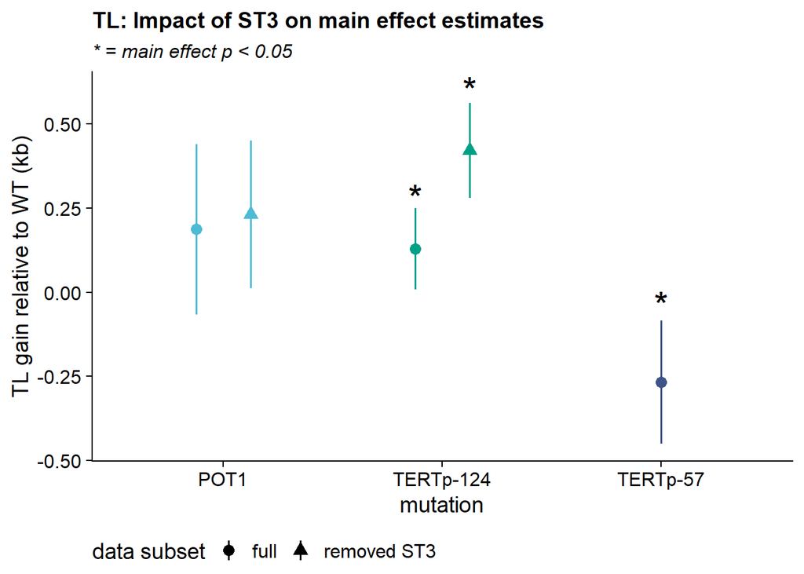

Below is a numeric summary of the results from performing regression with **eq. 1**, including estimates with and without ST3:

Table 1: Main effect of mutation on TL

| Data subset | Mutation | Effect (kb) | 95% CI | t value | p |
| --- | --- | --- | --- | --- | --- |
| full | TERTp-124 | 0.129 | [0.008, 0.249] | 2.094 | 3.73e-02 |
|  | TERTp-57 | -0.268 | [-0.450, -0.085] | -2.874 | 4.39e-03 |
|  | POT1 | 0.187 | [-0.066, 0.440] | 1.446 | 1.55e-01 |
| removed ST3 | TERTp-124 | 0.422 | [0.281, 0.563] | 5.853 | 1.34e-07 |
|  | POT1 | 0.232 | [0.012, 0.451] | 2.070 | 5.82e-02 |

### 2.2 Within-individual effects

Due to lower sample sizes within each individual (relative to the main effects estimated above across the data set), we limited power to detect statistically significant differences between *mutation* levels within each individual. *Note that we also do not account for pseudo-replication due to phylogenetic nonindependence – this would further deplete our power.*

Below is a summary of these contrasts with the revised model (**eq. 2**):

Table 2: Intra-individual effects of mutation on TL

| Individual | Contrast | ΔTL (kb) | 95% CI | t ratio | p |
| --- | --- | --- | --- | --- | --- |
| ST2 | WT - (TERTp-124) | -0.170 | [-0.389, 0.049] | -1.524 | 1.29e-01 |
| ST3 | WT - (TERTp-124) | 0.384 | [0.193, 0.574] | 3.943 | 2.98e-04 |
|  | WT - (TERTp-57) | 0.520 | [0.331, 0.710] | 5.379 | 4.72e-07 |
|  | (TERTp-124) - (TERTp-57) | 0.137 | [-0.053, 0.327] | 1.409 | 3.37e-01 |
| ST4 | WT - POT1 | -0.206 | [-0.481, 0.069] | -1.467 | 1.43e-01 |
| ST5 | WT - (TERTp-124) | -0.565 | [-0.759, -0.371] | -5.700 | 3.02e-08 |

The initial manuscript submission used the following mixed effects model to compare TL estimates between *mutation* levels within each individual:

$$\textrm{telomere length} \sim
\textrm{mutation} \times \textrm{individual + sensitivity} +
(1|\textrm{batch}). \tag{3}$$

Below we compare estimates made between the old model (**eq. 3**) and the new model (**eq. 2**). As *individual* and *batch* are largely captured by PC1, it is not surprising that we resolve minimal differences in our contrast estimates between the old and new models – suggesting our approach for capturing technical variation via batch labels was sufficient.

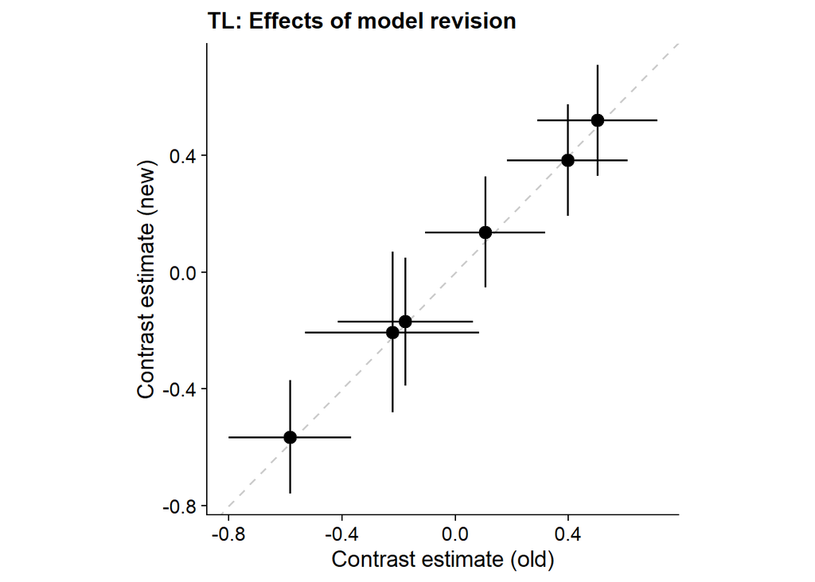

### 2.3 Summary

There is a measurable improvement in model fit using **eq. 2** (MSE = 0.14)over **eq. 3** (MSE = 0.18), and this is recapitulated by Akaiki information criterion strongly favoring **eq. 2** ($\Delta\textrm{AIC} = \textrm{AIC}_{eq2} - \textrm{AIC}_{eq3}$ = -64.3). As such, all TL-estimates for clone data will be updated to reflect the revised model.

Due to pseudo-replication of clonal data within individuals (by phylogenetic independence) and heterogeneity in both effect size (and sign) across individuals (e.g., *TERTp* -124C>T in ST2 vs. ST3), the main effect estimates presented in this notebook may not be reproducible in larger cohorts. As such, intra-individual effects are more reliable; however, pseudo-replication still impacts intra-individual effect estimates as well.

## 3. Clocklike-burden regressions

Following the same motivations as with the TL measurements above, we applied the same residualization technique to clocklike mutation burden estimates.

As with the revisions above, we exclude the *batch* due to its nesting within *individual.* Main effects (**eq. 4**) and intra-individual effects (**eq. 5**) are estimated using the same procedures described above. Here, however, we use a negative binomial generalized linear model to accommodate over-dispersed count data.

$$\textrm{clock-like burden} \sim
\textrm{mutation + sensitivity} + \sum_{i \in
1,...,k}^{k}\textrm{PC}_{i} + (1|\textrm{individual})
\tag{4}$$

$$\textrm{clock-like burden} \sim
\textrm{mutation} \times \textrm{individual + sensitivity} + \sum_{i \in
1,...,k}^{k}\textrm{PC}_{i} \tag{5}$$

### 3.1 Main effect of mutation

Consistent with the TL estimates above, main effect estimates are presented with and without including ST3 in the data using **eq. 4**.

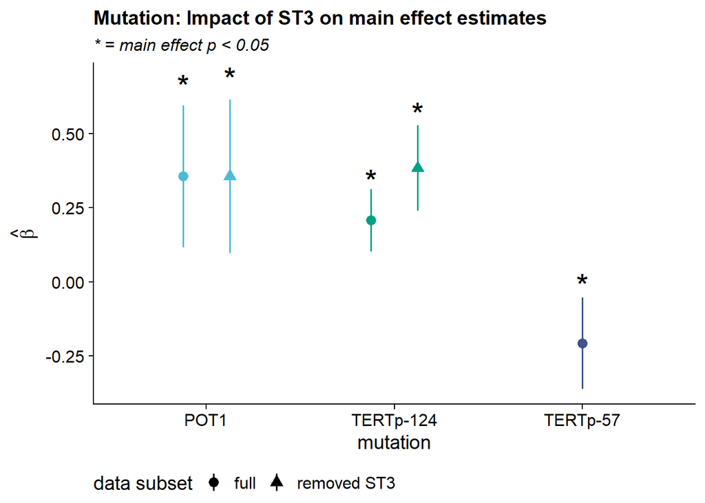

Similar to the TL results above, inclusion of ST3 has a measurable impact on the effect estimate for *TERTp* -124C>T. A table summarizing these data are below; note that each incidence rate ratio (IRR) is relative to WT in the following table:

Table 3: Main effect of mutation on clocklike mutation burden

| Data subset | Mutation | IRR | 95% CI | z value | p |
| --- | --- | --- | --- | --- | --- |
| full | TERTp-124 | 1.231 | [1.108, 1.367] | 3.875 | 1.07e-04 |
|  | TERTp-57 | 0.813 | [0.697, 0.948] | -2.638 | 8.35e-03 |
|  | POT1 | 1.428 | [1.124, 1.815] | 2.913 | 3.58e-03 |
| removed ST3 | TERTp-124 | 1.469 | [1.270, 1.698] | 5.196 | 2.03e-07 |
|  | POT1 | 1.428 | [1.102, 1.850] | 2.694 | 7.06e-03 |

### 3.2 Within-individual effects

Following the same format as the TL regressions section, we present a summary of the within individual effects as a table below. Here, IRR numerators and denominators are explicitly shown in the contrast field.

Table 4: Intra-individual effects of mutation on clocklike mutation burden

| Individual | Contrast | IRR | 95% CI | z ratio | p |
| --- | --- | --- | --- | --- | --- |
| ST2 | WT / (TERTp-124) | 0.546 | [0.444, 0.649] | -6.325 | 2.53e-10 |
| ST3 | WT / (TERTp-124) | 1.097 | [0.920, 1.274] | 1.122 | 5.01e-01 |
|  | WT / (TERTp-57) | 1.414 | [1.186, 1.642] | 4.216 | 7.37e-05 |
|  | (TERTp-124) / (TERTp-57) | 1.290 | [1.081, 1.498] | 3.081 | 5.85e-03 |
| ST4 | WT / POT1 | 0.714 | [0.548, 0.880] | -2.836 | 4.57e-03 |
| ST5 | WT / (TERTp-124) | 0.801 | [0.669, 0.932] | -2.661 | 7.79e-03 |

In the table below, we translate the IRR estimates into *clock-like mutation burden,* and subsequently these *clock-like burdens* to “years” for each *mutation* comparison against WT (within individuals). We use the genome-wide somatic mutation rate average of $\mu = 16.8$ mutations per cell per year presented in [Mitchell et al. 2022](https://www.nature.com/articles/s41586-022-04786-y).

Table 5: Clock-like mutation burden difference relative to WT

| Individual | Mutant | Diff. | Diff. 95% CI | Diff. Years | Diff. Years 95% CI |
| --- | --- | --- | --- | --- | --- |
| ST2 | TERTp-124 | 124 | [100, 153] | 7.358 | [5.935, 9.122] |
| ST3 | TERTp-124 | -28 | [-22, -35] | -1.653 | [-1.327, -2.055] |
|  | TERTp-57 | -92 | [-77, -111] | -5.486 | [-4.561, -6.598] |
| ST4 | POT1 | 119 | [111, 124] | 7.057 | [6.631, 7.356] |
| ST5 | TERTp-124 | 92 | [64, 130] | 5.499 | [3.786, 7.716] |

Comparing the performance of **eq.5** to **eq.6** in fitting *clock-like mutation burden***,** we don’t observe the same increase in performance as measured in the TL section.

$$\textrm{clock-like burden} \sim
\textrm{mutation} \times \textrm{individual + sensitivity} +
(1|\textrm{batch}) \tag{6}$$

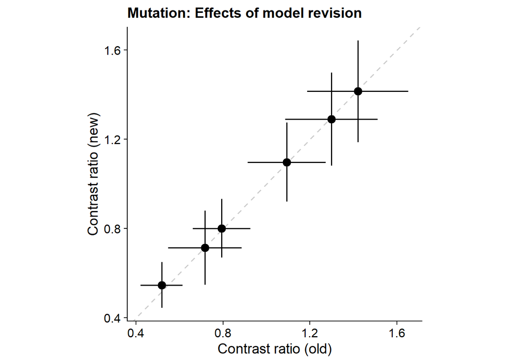

### 3.3 Summary

Including PCs in lieu of *batch* labels does not improve model fit or estimates when regressing *clock-like burden* onto our biological predictors. AIC reinforces this conclusion, as the $\Delta\textrm{AIC}$ between **eq. 5** and **eq. 6** is -2.71. However, to remain consistent with the model structure described for TL section the updated model is preferred.

Repeating the same recommendations as made in the summary of the TL section, effect heterogeneity and pseudo-replication make it difficult to generalize main effect estimates made for each mutation on clock-like mutation burden.

## 4. Predicting TL by clock-like burden

Combining the models above, we’ll predict the effect of clock-like burden on TL, where the interpretable unit would be, “$\hat{Y}$ bases of additional TL per 100 bases of clock-like mutations.” **Eq. 7** captures the revised model, and **eq. 8** is the version presented in the initial submission. For both, we’ll use a linear mixed effects model, including *individual* as a random effect and the *clock-like burden* is pre-adjusted for sequencing sensitivity using the metric described in 1. Data summary.

$$\textrm{telomere length} \sim
\textrm{adj. clock-like burden + mutation + sensitivity} + \sum_{i \in
1,...,k}^{k}\textrm{PC}_{i} + (1|\textrm{individual})
\tag{7}$$

$$\textrm{telomere length} \sim
\textrm{adj. clock-like burden + mutation + sensitivity} +
(1|\textrm{individual}) \tag{8}$$

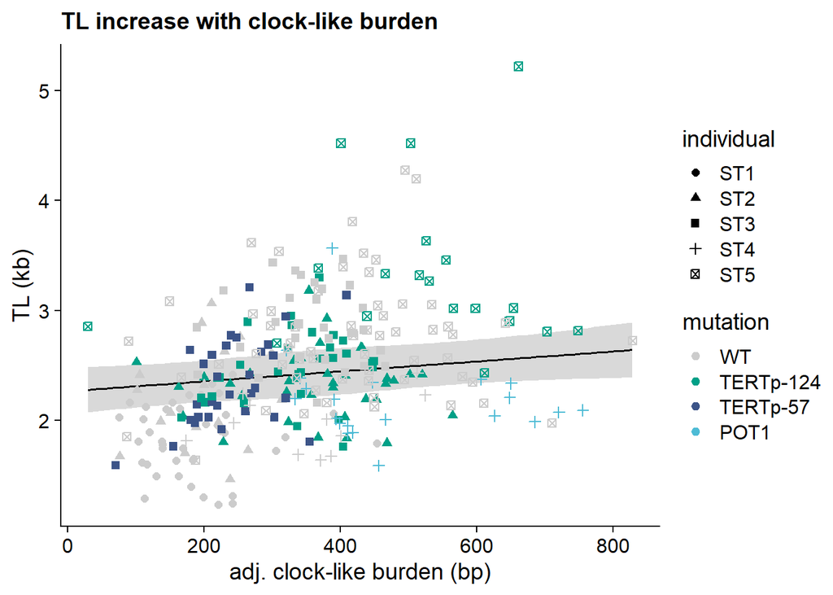

Akin to the TL regression section, including PCs (**eq. 7**) significantly improves model fit $\Delta \textrm{AIC}$ = -64.9542098. Notably, however, exclusion of ST3 from the data set eliminates statistical significance. Below, we report the estimates from (**eq. 7**) with and without ST3. Instability of main effect estimates of clock-like burden on TL further fortifies the intra-individual contrasts as the more reliable quantities. However, these values are not presented below, as we do not report this relationship in the manuscript.

Table 6: TL (bp) per 100 clock-like SNVs

| Subset | Estimate | 95% CI | t value | p |
| --- | --- | --- | --- | --- |
| Full | 45.231 | [7, 88] | 2.118 | 0.035 |
| Without ST3 | 3.520 | [-39, 49] | 0.154 | 0.878 |